# Question Solving Version 2.0

```r
cat("Variance of median order statistics:", var_median, "\n")
```

[output not shown]

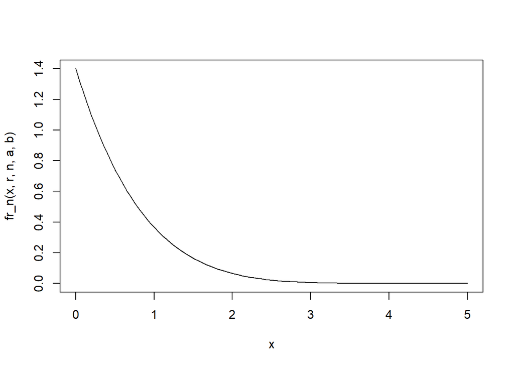

```r
plot(x, fr_n(x, r, n, a, b), type = "l")
```

```r
mean_x1_n = moment_k(k=1, r=1, n, a, b)
var_x1_n = moment_k(k=2, r=1, n, a, b) - mean_x1_n^2

mean_xn_n = moment_k(k=1, r=n, n, a, b)
var_xn_n = moment_k(k=2, r=n, n, a, b) - mean_xn_n^2

cat("Smallest order statistics: mean =", mean_x1_n, "and variance =", var_x1_n, "\n")
```

```
## Smallest order statistics: mean = 0.625 and variance = 0.3038194
```

```r
cat("Largest order statistics: mean =", mean_xn_n, "and variance =", var_xn_n, "\n")
```

```
## Largest order statistics: mean = 4.375 and variance = 0.3038194
```

**Problem 5: Suppose $X_{1:7} < X_{2:7} < X_{3:7} < X_{4:7} < X_{5:7} < X_{6:7} < X_{7:7}$ denote the order statistics based on a random sample of size 7 from the distribution having probability density function (pdf) $f(x) = \frac{1}{10}; 0 \le x \le 10$. Evaluate the mean and variance of the $5^{th}$ order statistic $(X_{5:7})$ and plot the CDF of the $5^{th}$ order statistic.**

```r
fr_n = function(x, r, n, a, b) {
  pdf_x <- dunif(x, min=a, max=b)
  cdf_x <- punif(x, min=a, max=b)

  numerator <- factorial(n) / (factorial(r-1)*factorial(n-r))
  prob_dis <- numerator * cdf_x^(r-1) * (1 - cdf_x)^(n-r) * pdf_x

  return(prob_dis)
}

moment_k <- function(k, r, n, a, b) {
  integrand <- function(x) x^k * fr_n(x, r, n, a, b)
  moment <- integrate(integrand, a, b)$value

  return(moment)
}
a = 0
b = 10
r = 5
n = 7
x = seq(a, b, length.out = 100)

mean_x5 <- moment_k(k=1, r, n, a, b)
var_x5 <- moment_k(k=2, r, n, a, b) - mean_x5^2

cat("Mean of X_{(5)}:", mean_x5, "\n")
```

```
## Mean of X_{(5)}: 6.25
```

```r
cat("Variance of X_{(5)}:", var_x5, "\n")
```

```
## Variance of X_{(5)}: 2.604167
```

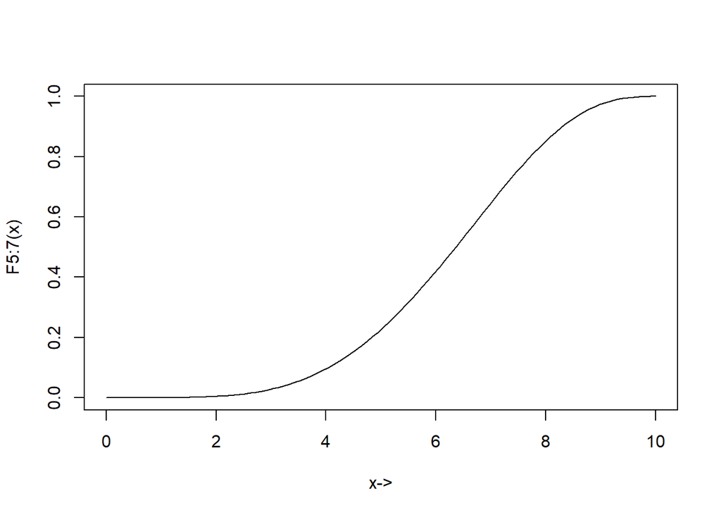

```r
Fr_n_values <- array()
for(i in 1:100) {
  Fr_n_values[i] = integrate(fr_n, a, x[i], r=r, n=n, a=a, b=b)$value
}

plot(x, Fr_n_values, type = "l", xlab = "x->", ylab=paste0("F", r, ":", n, "(x)"))
```

**Problem 6: A random sample of size 3 is drawn from a population that has a uniform distribution on the interval (0, 1). The resulting order statistics are $X_{1:3}, X_{2:3}$ and $X_{3:3}$. Determine the mean and variance of smallest and largest order statistic.**

### Method 1:

*kth raw moment of rth order statistics of uniform distribution on the interval [0, 1] is $\mu_{r:n}^{(k)} = \frac{n!\cdot (k+r-1)!}{(r-1)! \cdot (k+n)!}$*

```r
rm_unif_r_n <- function(k, r, n) {
  result <- (factorial(n)*factorial(k+r-1))/(factorial(r-1)*factorial(k+3))
  return(result)
}

n = 3
mean_x1_3 = rm_unif_r_n(k=1, r=1, n)
var_x1_3 = rm_unif_r_n(k=2, r=1, n) - mean_x1_3^2

mean_x3_3 = rm_unif_r_n(k=1, r=3, n)
var_x3_3 = rm_unif_r_n(k=2, r=3, n) - mean_x3_3^2

cat("Smallest order statistics: mean =", mean_x1_3, "and variance =", var_x1_3, "\n")
```

```
## Smallest order statistics: mean = 0.25 and variance = 0.0375
```

```r
cat("Largest order statistics: mean =", mean_x3_3, "and variance =", var_x3_3, "\n")
```

```
## Largest order statistics: mean = 0.75 and variance = 0.0375
```

### Method 2:

```r
fr_n = function(x, r, n, a, b) {
  pdf_x <- dunif(x, a, b)
  cdf_x <- punif(x, a, b)

  numerator <- factorial(n) / (factorial(r-1)*factorial(n-r))
  prob_dis <- numerator * cdf_x^(r-1) * (1-cdf_x)^(n-r) * pdf_x

  return(prob_dis)
}

moment_k <- function(k, r, n, a, b) {
  integrand <- function(x) x^k * fr_n(x, r, n, a, b)
  moment <- integrate(integrand, a, b)$value
  return(moment)
}

a = 0
b = 1
n = 3

colors = c("red", "blue")

x <- seq(a, b, length.out = 100)
mean_x1_3 = moment_k(k=1, r=1, n, a, b)
var_x1_3 = moment_k(k=2, r=1, n, a, b) - mean_x1_3^2
mean_x3_3 = moment_k(k=1, r=3, n, a, b)
var_x3_3 = moment_k(k=2, r=3, n, a, b) - mean_x3_3^2

cat("Smallest order statistics: mean =", mean_x1_3, "and variance =", var_x1_3, "\n")
```

```
## Smallest order statistics: mean = 0.25 and variance = 0.0375
```

```r
cat("Largest order statistics: mean =", mean_x3_3, "and variance =", var_x3_3, "\n")
```

```
## Largest order statistics: mean = 0.75 and variance = 0.0375
```

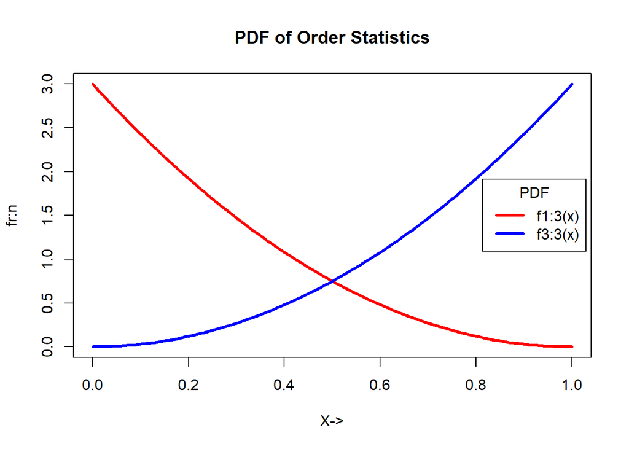

```r
plot(x, fr_n(x, r=1, n, a, b), type = "l", col=colors[1], lwd=3, main = "PDF of Order Statistics", xlab = "X->", ylab = "fr:n")
lines(x, fr_n(x, r=3, n, a, b), col = colors[2], lwd=3)

legend("right", inset = 0.01, title = "PDF", c("f1:3(x)", "f3:3(x)"), lty=1, lwd=3, col=colors)
```

**Problem 7: A random sample of size 3 is drawn from a population that has a uniform distribution on the interval (0, 1). The resulting order statistics are $X_{1:3}, X_{2:3}, X_{3:3}$. Determine the mean and variance of sample range.**

```r
fr_n = function(x, r, n, a, b) {
  pdf_x = dunif(x, min=a, max=b)
  cdf_x = punif(x, min=a, max=b)

  numerator <- factorial(n) / (factorial(r-1)*factorial(n-r))
  prob_dist <- numerator * cdf_x^(r-1) * (1 - cdf_x)^(n-r)*pdf_x

  return(prob_dist)
}

a = 0
b = 1
n = 3
x = seq(0, 1, length.out=100)

moment_k <- function(k, r, n, a, b) {
  integrand <- function(x) x^k * fr_n(x, r, n, a, b)
  moment <- integrate(integrand, a, b)$value
  return(moment)
}

exp_xy <- function(n, a, b) {
  integrand <- function(x) {
    f_y <- function(y) n*(n-1)*x*y*(y-x)
    # integration from x to b (dependent range)
    integrate(Vectorize(f_y), x, b)$value
  }

  # integration from a to b
  result <- integrate(Vectorize(integrand), a, b)$value
  return(result)
}

mean_x1_n = moment_k(k=1, r=1, n, a, b)
var_x1_n = moment_k(k=2, r=1, n, a, b) - mean_x1_n^2

mean_xn_n = moment_k(k=1, r=n, n, a, b)
var_xn_n = moment_k(k=2, r=n, n, a, b) - mean_xn_n^2

cat("Smallest order statistics: mean =", mean_x1_n, "and variance =", var_x1_n, "\n")
```

```
## Smallest order statistics: mean = 0.25 and variance = 0.0375
```

```r
cat("Largest order statistics: mean =", mean_xn_n, "and variance =", var_xn_n, "\n")
```

```
## Largest order statistics: mean = 0.75 and variance = 0.0375
```

```r
cov_order = exp_xy(n, a, b) - (mean_x1_n * mean_xn_n)

cat("Covariance of smallest and largest order statistics =", cov_order, "\n")
```

```
## Covariance of smallest and largest order statistics = 0.0125
```

```r
mean_sample_range = (mean_xn_n - mean_x1_n)
var_sample_range = var_x1_n + var_xn_n - 2*cov_order

cat("Mean of sample range:", mean_sample_range, "\n")
```

```
## Mean of sample range: 0.5
```

```r
cat("Variance of sample range:", var_sample_range, "\n")
```

```
## Variance of sample range: 0.05
```

**Problem 8: The random sample $X_1, X_2, ..., X_9$ of size 9 is drawn from a population that has a uniform distribution with the interval (0, 10). Evaluate the mean and variance of 7th order statistic. Also find the value of $P(X_{7} > 2)$**

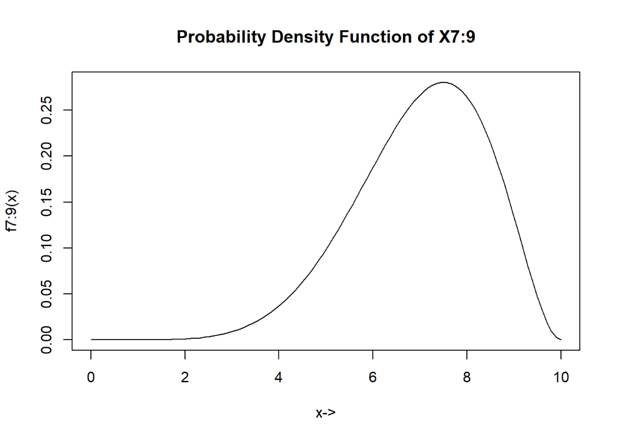

```r
fr_n = function(x, r, n, a, b) {
  pdf_x <- dunif(x, a, b)
  cdf_x <- punif(x, a, b)

  numerator <- factorial(n) / (factorial(r-1)*factorial(n-r))
  prob_dis <- numerator * cdf_x^(r-1) * (1-cdf_x)^(n-r) * pdf_x

  return(prob_dis)
}

a <- 0
b <- 10
n <- 9
r <- 7

x <- seq(a, b, length.out=100)

fr_n_values <- sapply(x, fr_n, r=r, n=n, a=a, b=b)

plot(x, fr_n_values, type = "l", xlab = "x->",
     ylab = paste0("f", r, ":", n, "(x)"),
     main = paste0("Probability Density Function of X", r, ":", n))
```

```r
moment_k <- function(k, r, n, a, b) {
    integrand <- function(x) x^k * fr_n(x, r, n, a, b)
    moment <- integrate(integrand, a, b)$value
    moment
}

mean_x7 <- moment_k(1, r, n, a, b)
var_x7 <- moment_k(2, r, n, a, b) - mean_x7^2

cat("Mean of X_{(7)}:", mean_x7, "\n")
```

```
## Mean of X_{(7)}: 7
```

```r
cat("Variance of X_{(7)}:", var_x7, "\n")
```

```
## Variance of X_{(7)}: 1.909091
```

```r
# int 2 to 10
p_x7_gt_2 <- integrate(fr_n, 2, b, r=r, n=n, a=a, b=b)$value
cat("P(X_{(7)} > 2):", p_x7_gt_2, "\n")
```

```
## P(X_{(7)} > 2): 0.9996861
```